# Exercise 13

Chenwei Xiao

2020/12/09

This exercise has two parts.

In the **first** part you will create a feed forward neural network using only the NDVI image as input. In this case each pixel of the image is considered as a feature.

In the **second** part you have to create a mixed model. As we have already seen in tutorial 13, categorical features can also be incorporated into a neural network model. Specifically, in tutorial 13, a mixed model combining the CNN features and the tower location (as a categorical feature) is created. The goal of this part is to also incorporate the corresponding month for each NDVI input image along with the tower location. The reason for such a refinement is that seasonality plays an important role in vegetation metabolism and therefore can affect the CO2 fluxes.

For the **second** part a skeleton code is provided. You have only to fill in the missing code where is necessary. Is there an improvement in the model performance on the validation and test set?

Yes, there is an adequate improvement in the model performance in both validation and test set.

### Import libraries

```r
library(imputeTS) # Library for Imputation
library(tidyverse)
library(reticulate)
use_condaenv()
library(keras) # Python library for deep learning
library(tensorflow)
```

IMPORTANT NOTE: READ CAREFULLY!

Do not skip this part or you’ll run into issues later on! In a moment, after you’ve read the following instructions carefully, you should: - run the code chunk immediately below this text (`keras_model_sequential()`). - look down in the *Console* it asks if you want to install some packages: (“Would you like to install Miniconda? [Y/n]:”). - write *n* and press enter. You should see the following code in the console: `Would you like to install Miniconda? [Y/n]: n`. Now, you can normally continue with the exercise.

If you were too eager and already pressed *Y* (yes) and enter, don’t panic! Just close your environment, re-open it and make sure that next time you go with *n* (no).

```r
keras_model_sequential()
```

### Read in the data

```r
#read in the data
path = "../../data"

##tower features
train=readRDS(file.path(path,'train','towers_feature','features.rds'))
val=readRDS(file.path(path,'validation','towers_feature','features.rds'))
test=readRDS(file.path(path,'test','towers_feature','features.rds'))

# have a look
head(train)
```

```
##      tower year month        co2
## 112 BE_Bra 2009     5 -2.5946352
## 126 BE_Bra 2010     7 -2.1514027
## 138 BE_Bra 2011     7 -3.1261510
## 54  BE_Bra 2004     7 -2.1701580
## 104 BE_Bra 2008     9 -0.5906272
## 161 BE_Bra 2013     6 -4.0140262
```

```r
## take CO2 flux
y_train = train$co2
y_val = val$co2
y_test =  test$co2
##ndvi images
ndvi_train = readRDS(file.path(path,'train','NDVI','ndvi_train.rds'))
ndvi_val =  readRDS(file.path(path,'validation','NDVI','ndvi_val.rds'))
ndvi_test = readRDS(file.path(path,'test','NDVI','ndvi_test.rds'))

#print some statistics of the data
paste("Size of training set is ",length(y_train))
```

```
## [1] "Size of training set is  3366"
```

```r
paste("Size of validation set is ",length(y_val))
```

```
## [1] "Size of validation set is  766"
```

```r
paste("Size of test set is ",length(y_test))
```

```
## [1] "Size of test set is  648"
```

### Preprocess NDVI images

```r
#specify image size
IMAGE_WIDTH = dim(ndvi_train)[2]
IMAGE_HEIGHT = dim(ndvi_train)[3]
IMAGE_CHANNELS = 1
IMAGE_SIZE = c(IMAGE_WIDTH,IMAGE_HEIGHT,IMAGE_CHANNELS)


#fill in the missing values , rescale images to [0,1] , reshape to be a valid input for a NN

preprocess_images = function(ndvi){

  min_ndvi = -2000
  max_ndvi = 10000

  #fill missing values
  nd = apply(ndvi,c(2,3),function(i) na_interpolation(i))

  #rescale to [0,1]
  nd = (nd-min_ndvi)/(max_ndvi-min_ndvi)

  #reshape adding an extra dimension
  nd = array_reshape(nd,dim=c(-1,IMAGE_SIZE))

  return (nd)
}

#take preprocessed images
ndvi_train_pr = preprocess_images(ndvi_train)
ndvi_val_pr = preprocess_images(ndvi_val)
ndvi_test_pr = preprocess_images(ndvi_test)
```

## Part 1

### Create a feed forward neural network using only the NDVI image

This model should be more complex than the one provided in tutorial 13

```r
#ffnn
model <- keras_model_sequential()
model %>% layer_flatten(input_shape = IMAGE_SIZE) %>%
  layer_dense(units = 64,activation = 'relu') %>%
  layer_dense(units = 32,activation = 'relu') %>%
  layer_dense(units = 16,activation = 'relu') %>%
  layer_dense(units=1)

summary(model)
```

```
## Model: "sequential"
## ________________________________________________________________________________
## Layer (type)                        Output Shape                    Param #
## ================================================================================
## flatten (Flatten)                   (None, 4356)                    0
## ________________________________________________________________________________
## dense (Dense)                       (None, 64)                      278848
## ________________________________________________________________________________
## dense_1 (Dense)                     (None, 32)                      2080
## ________________________________________________________________________________
## dense_2 (Dense)                     (None, 16)                      528
## ________________________________________________________________________________
## dense_3 (Dense)                     (None, 1)                       17
## ================================================================================
## Total params: 281,473
## Trainable params: 281,473
## Non-trainable params: 0
## ________________________________________________________________________________
```

### Train the model

Hint: In tutorial 13 you can find some ideas on how to train the model and which are the proper callbacks to use

```r
#optimizer
opt=optimizer_adam(lr=0.01)

#compile
model %>%
  compile(loss = 'mse',optimizer = opt,metrics=list('mse'))

#file path for ffnn
dir.create('saved_models')
dir.create(file.path('saved_models','FFNN'))
save_path_ffnn = file.path('saved_models','FFNN')

#callbacks for FFNN
callbacks_ffnn = list(
  callback_model_checkpoint(file.path(save_path_ffnn,"model_p1.h5"),monitor='val_loss',save_best_only = T,mode = 'min'),
  callback_reduce_lr_on_plateau(monitor = "val_loss",patience = 5 ,factor = 0.1),
  callback_early_stopping(monitor='val_loss',patience = 10,mode = 'min')
)
```

```r
# train the model
history_ffnn <- model %>%
  fit(x = ndvi_train_pr,y = y_train,
      batch_size = 128,
      epochs = 200,
      shuffle = T,
      validation_data=list(ndvi_val_pr,y_val),
      callbacks = callbacks_ffnn
      )
```

### Plot the training history

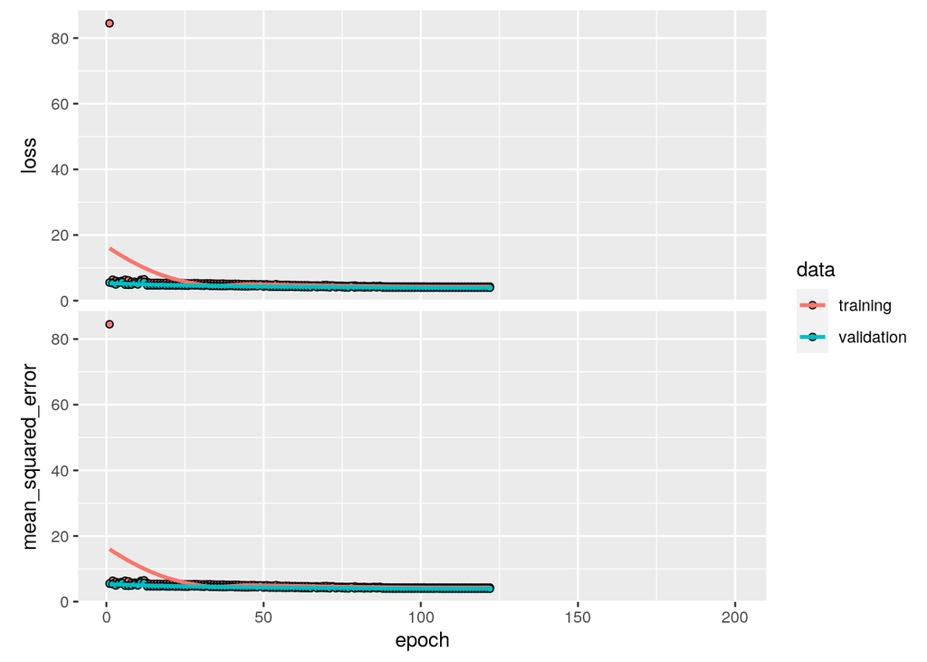

```r
#save model history
#saveRDS(history_ffnn,file = file.path(save_path_ffnn,'p1_history.rds'))

#load pretained models history
history_p1 = readRDS('./saved_models/FFNN/p1_history.rds')

#plot ffnn history
plot(history_p1)
```

### Load the trained model and evaluate performance on validation and test set

Hint: In tutorial 13 we have already seen how to retrieve a trained model made by the checkpoint callback.

```r
# define mse
mse = function(model,x,y){
  pr = predict(model,x)
  return (round(mean((pr-y)^2),2))
}
# load the trained model in p1
model_p1 <- load_model_hdf5(file.path(save_path_ffnn,"model_p1.h5"))

ffnn_val_mse = mse(model_p1,ndvi_val_pr,y_val)
ffnn_test_mse = mse(model_p1,ndvi_test_pr,y_test)

#create dataframe with results
results = data.frame(Model = c('FFNN'),
                     Val_MSE = c(ffnn_val_mse),
                     Test_MSE = c(ffnn_test_mse))

results
```

```
##   Model Val_MSE Test_MSE
## 1  FFNN    3.95     4.37
```

## Part 2

### Create a mixed model: CNN features + tower location + month

In this model we want to incorporate the month of the NDVI input image along with CNN features and the tower location. Our goal is to insert categorical features inside a neural network model and to examine if the performance can be further improved. Obviously, a model which can take into account extra information about the NDVI input image, such as the month that the image was taken, and the spatial location of it makes it more realistic. As a result, further improvement of the model performance can be expected.

Below, you’ll have to fill in some missing code in order to create the model.

```r
create_mixed <- function(){

  #input --> ndvi images
  input_1 = layer_input(shape=IMAGE_SIZE)

  #input --> tower + month
  input_2 = layer_input(shape=c(2))

  # cnn layer
  cnn_layer = layer_conv_2d(input_1,filters = 4, kernel_size = c(3,3), activation = 'relu',padding = 'same')

  # pool layer
  pool =  layer_max_pooling_2d(cnn_layer,pool_size = c(3, 3))

  # cnn layer
  cnn_layer_2 = layer_conv_2d(pool,filters = 16,kernel_size = c(3,3),activation = 'relu', padding = 'same')

  # pool layer
  pool_2 =  layer_max_pooling_2d(cnn_layer_2,pool_size = c(3,3))

  # drop some features to avoid overfitting
  drop_ft = layer_dropout(pool_2,rate = 0.2)

  # flatten the features
  flat = layer_flatten(drop_ft)

  # mlp of the features --> project to dim 64
  flat_proj = layer_dense(flat,units = 64,activation = 'relu')


  # features --> tower , month

  #tower embedding --> input_dim = 34 (number of discrete towers), output_dim = 10 (number of requested trainable weights)
  tower_emb = layer_embedding(input_2[,1],input_dim = 34,output_dim = 10)
  #reshape
  tower_emb = k_reshape(tower_emb,shape = c(-1,10))

  #month embedding --> input_dim = 12 (number of discrete months), output_dim = 10 (number of requested trainable weights)

  #FILL IN THE CODE
  #create an embedding layer for the month
  month_emb = layer_embedding(input_2[,2],input_dim = 12,output_dim = 10)
  #reshape
  month_emb = k_reshape(month_emb,shape = c(-1,10))

  #concatenate embeddings
  emb_concat = k_concatenate(list(tower_emb,month_emb))

  # ffnn of embedings
  emb_proj = layer_dense(emb_concat,units = 32,activation = 'relu')

  # concatenate cnn feautures and embeddings of tower and months
  ft_concat= k_concatenate(list(flat_proj,emb_proj))

  #output
  output =  layer_dense(ft_concat,units = 1, activation = 'linear')

  #create model
  model = keras_model(list(input_1,input_2),output)

  return(model)

}


model = create_mixed()

summary(model)
```

```
## Model: "model"
## ________________________________________________________________________________
## Layer (type)              Output Shape      Param #  Connected to
## ================================================================================
## input_1 (InputLayer)      [(None, 66, 66, 1 0
## ________________________________________________________________________________
## conv2d (Conv2D)           (None, 66, 66, 4) 40       input_1[0][0]
## ________________________________________________________________________________
## max_pooling2d (MaxPooling (None, 22, 22, 4) 0        conv2d[0][0]
## ________________________________________________________________________________
## input_2 (InputLayer)      [(None, 2)]       0
## ________________________________________________________________________________
## conv2d_1 (Conv2D)         (None, 22, 22, 16 592      max_pooling2d[0][0]
## ________________________________________________________________________________
## tf_op_layer_strided_slice [(None,)]         0        input_2[0][0]
## ________________________________________________________________________________
## tf_op_layer_strided_slice [(None,)]         0        input_2[0][0]
## ________________________________________________________________________________
## max_pooling2d_1 (MaxPooli (None, 7, 7, 16)  0        conv2d_1[0][0]
## ________________________________________________________________________________
## embedding (Embedding)     (None, 10)        340      tf_op_layer_strided_slice[0
## ________________________________________________________________________________
## embedding_1 (Embedding)   (None, 10)        120      tf_op_layer_strided_slice_1
## ________________________________________________________________________________
## dropout (Dropout)         (None, 7, 7, 16)  0        max_pooling2d_1[0][0]
## ________________________________________________________________________________
## tf_op_layer_Reshape (Tens [(None, 10)]      0        embedding[0][0]
## ________________________________________________________________________________
## tf_op_layer_Reshape_1 (Te [(None, 10)]      0        embedding_1[0][0]
## ________________________________________________________________________________
## flatten_1 (Flatten)       (None, 784)       0        dropout[0][0]
## ________________________________________________________________________________
## tf_op_layer_concat (Tenso [(None, 20)]      0        tf_op_layer_Reshape[0][0]
##                                                      tf_op_layer_Reshape_1[0][0]
## ________________________________________________________________________________
## dense_4 (Dense)           (None, 64)        50240    flatten_1[0][0]
## ________________________________________________________________________________
## dense_5 (Dense)           (None, 32)        672      tf_op_layer_concat[0][0]
## ________________________________________________________________________________
## tf_op_layer_concat_1 (Ten [(None, 96)]      0        dense_4[0][0]
##                                                      dense_5[0][0]
## ________________________________________________________________________________
## dense_6 (Dense)           (None, 1)         97       tf_op_layer_concat_1[0][0]
## ================================================================================
## Total params: 52,101
## Trainable params: 52,101
## Non-trainable params: 0
## ________________________________________________________________________________
```

### Tokenize tower location and month

```r
#create function which tokenizes tower and month

tokenize_data = function(data){

  #tokenize tower
  tower_token = rep(NA,length(data$tower))

  for ( i in 1:length(unique(data$tower))){
    ind_tow= which(data$tower==unique(data$tower)[i])
    tower_token[ind_tow]=i-1
  }

  #tokenize month
  month_token = data$month -1

  return (as.matrix(data.frame(tower_token = tower_token,month_token = month_token)))
}


# take tokens of tower , year , month
train_tokens = tokenize_data(train)
val_tokens = tokenize_data(val)
test_tokens = tokenize_data(test)
```

### Train the model

```r
# optimizer
opt=optimizer_adam(lr=0.01)

#file path for mixed
dir.create('saved_models')
dir.create(file.path('saved_models','Mixed'))
save_path_mixed = file.path('saved_models','Mixed')

# callback for mixed
callbacks_mixed = list(
  callback_model_checkpoint(file.path(save_path_mixed,"model_mixed.h5"),monitor='val_loss',save_best_only = T,mode = 'min'),
  callback_reduce_lr_on_plateau(monitor = "val_loss",patience = 5 ,factor = 0.1),
  callback_early_stopping(monitor='val_loss',patience = 10,mode = 'min')
)

#compile
compile(model,loss = 'mse',optimizer = opt,metrics=list('mse'))
```

```r
# train the model
history_mixed = fit(model,x = list(ndvi_train_pr,train_tokens),y = y_train,
                    batch_size = 128,
                    epochs = 200,
                    shuffle = T,
                    validation_data = list(list(ndvi_val_pr,val_tokens),y_val),
                    callbacks = callbacks_mixed)
```

### Plot the training history

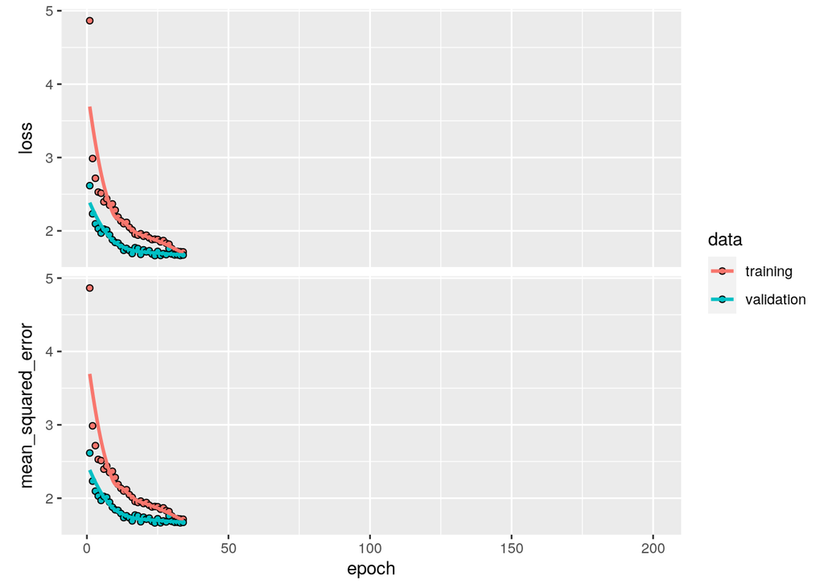

```r
# save mixed history
# saveRDS(history_mixed,file = file.path(save_path_mixed,'mixed_history.rds'))

#load pretained models history
history_mixed = readRDS('./saved_models/Mixed/mixed_history.rds')

#plot mixed history
plot(history_mixed)
```

### Load the trained model and evaluate performance on the validation and test set

```r
# define mse
mse = function(model,x,y){
  pr = predict(model,x)
  return (round(mean((pr-y)^2),2))
}

#load models
model_mixed = load_model_hdf5(file.path(save_path_mixed,"model_mixed.h5"))

# Validation Mse
mixed_val_mse = mse(model_mixed,list(ndvi_val_pr,val_tokens),y_val)

#test mse
mixed_test_mse = mse(model_mixed,list(ndvi_test_pr,test_tokens),y_test)

#
cat('Validation MSE: ',mixed_val_mse,'\n')
```

```
## Validation MSE:  1.66
```

```r
cat('Test MSE: ',mixed_test_mse,'\n')
```

```
## Test MSE:  1.95
```

From the MSE of validation and test set, the model performance improves a lot in mixed NN.